# Project 1

Daniel Briseno and Emily Daskas

10/5/2020

### Research Question 1:

**Examine the association between the total bill and tip.**

*How does this relationship change based on sex, smoker status, and the combination of the two (i.e. male smokers, female non-smokers, etc.)?*

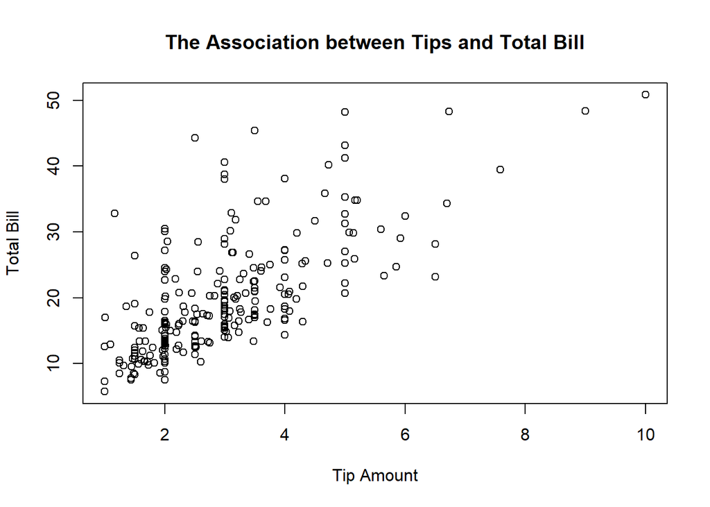

“The Relationship between Tips and Total Bill” plot, seen above, shows a positive relationship between the tip amount and the total bill. This makes sense because people will generally tip somewhere around 15-20% of their total bill, so as their bill increases, their tip should too.

We can now look more in depth and see how this relationship changes based on smoking status and sex.

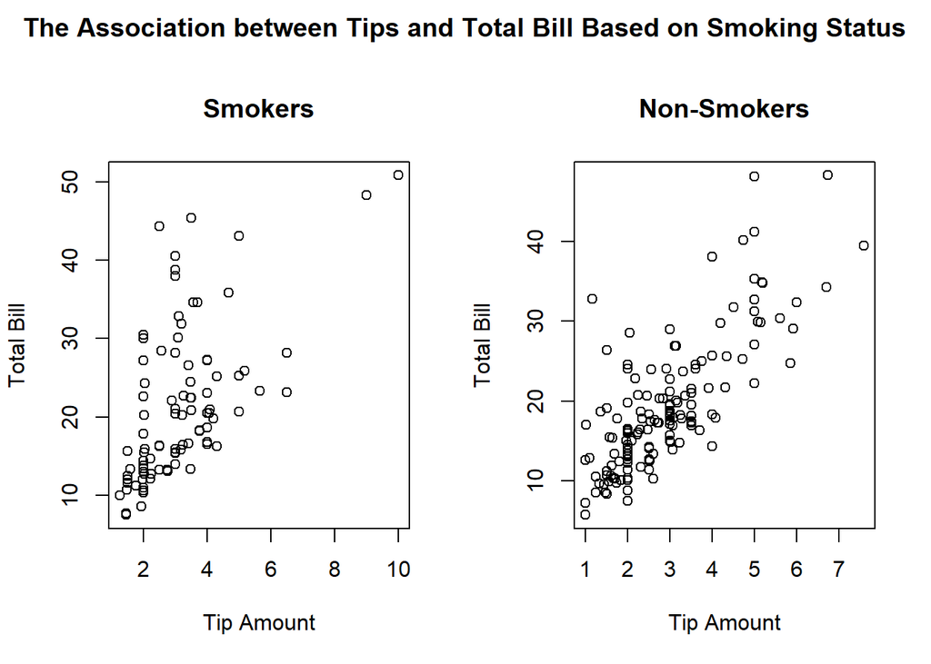

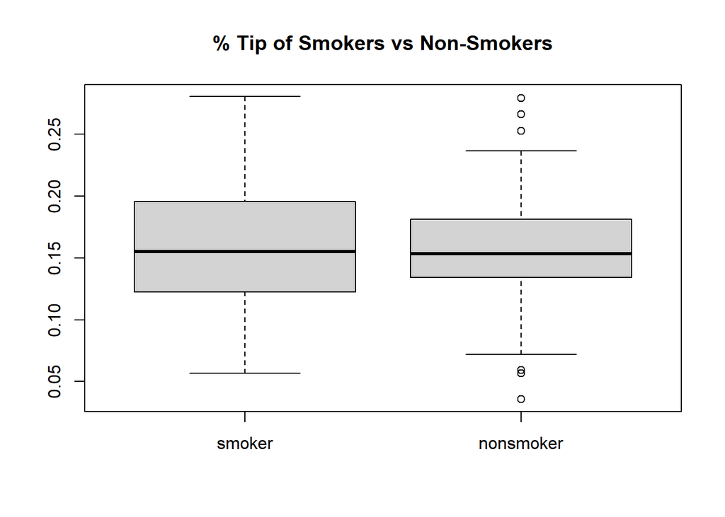

In the above plots, we examine this positive relationship between tips and total bill based on smoking status. As seen in the scatter plot, when separating by these groups, there is a strong, positive correlation between tip amount and total bill for the non-smoking group. However, it seems as though that relationship is less clear in the smoking group. This could be because smoking is often associated with drinking. The relationship in the smoking group is less linear. We can also see in the box plot that the median tip percent of both the smokers and non-smokers is very similar, but the spread is much different. Non-smokers tip percent is much more consistent, while with smokers, you are likely to get a wider range of tips.

Next, we will take the same approach, but examine tipping habits based on sex.

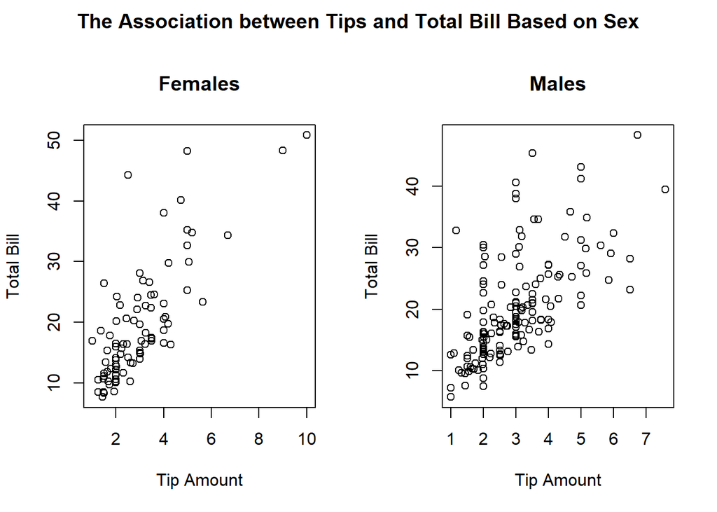

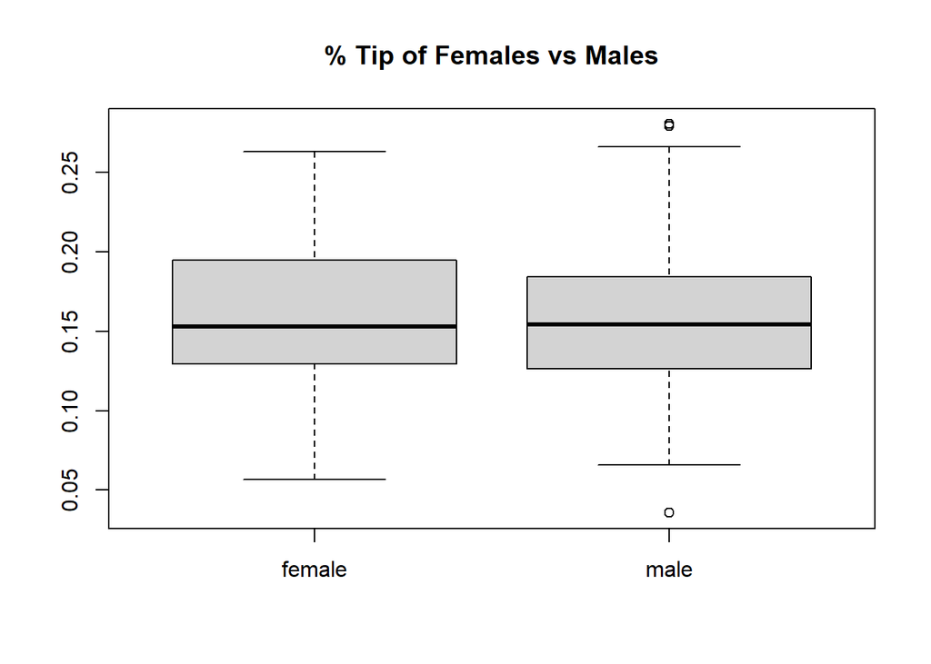

We can see in the plots above, that both males and females tip with similar habits. There is a positive, linear relationship between tips and total bill for both sexes. Interestingly, it seems as though females are more likely going to tip slightly higher than men as the spread of their inter quartile range is slightly higher than the male category.

After examining males vs females and smokers vs non-smokers, we can go further in depth and look at a combination of both.

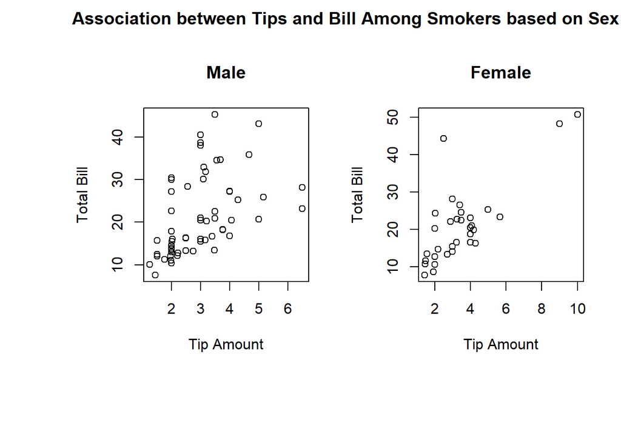

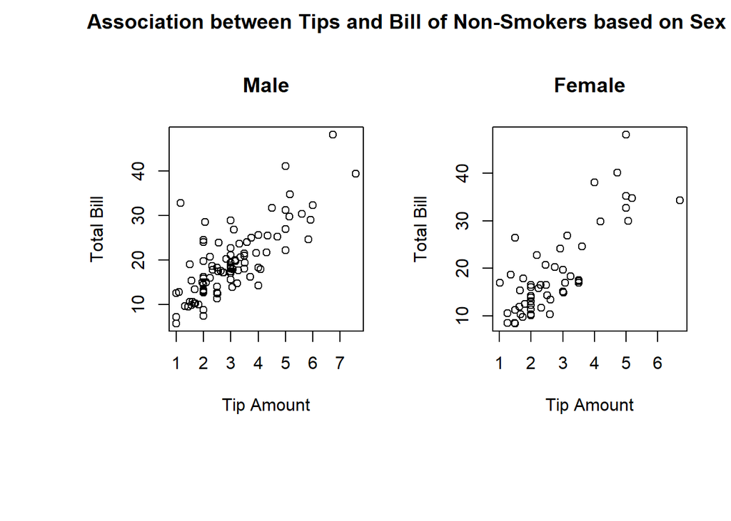

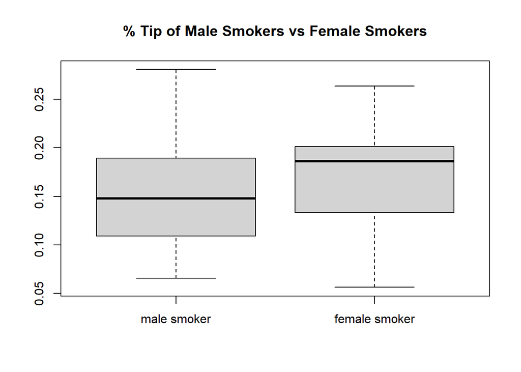

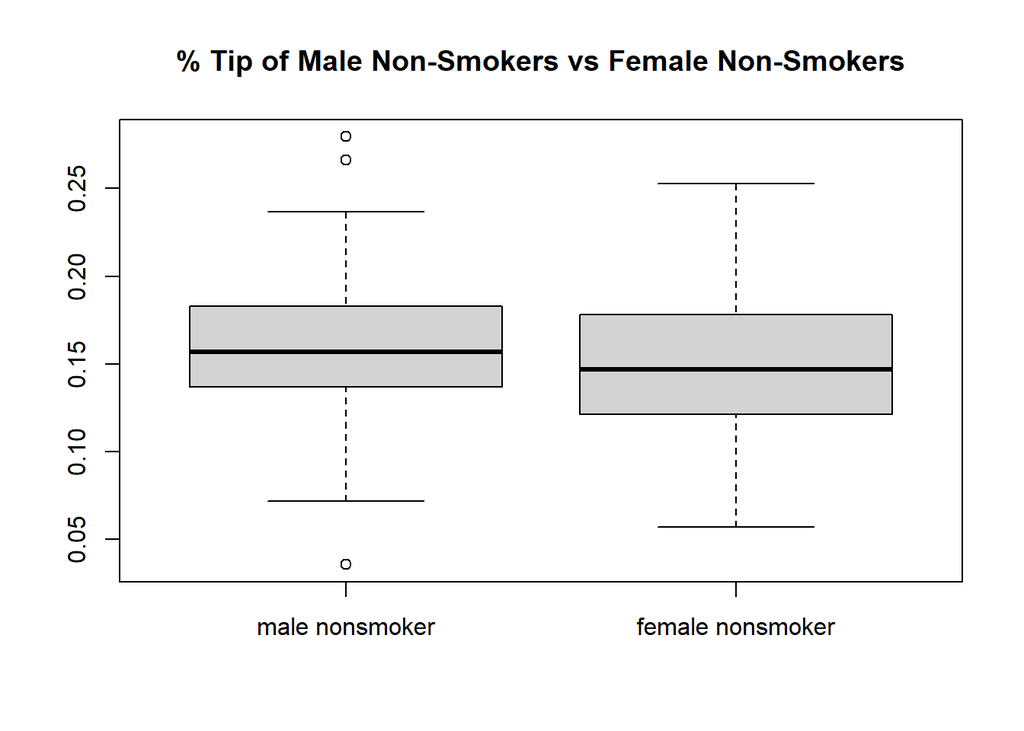

We find interesting differences in the above graphs. First, by looking at smokers, we can see that females will more consistently tip higher than men. The median percent of men is 15% while it is about 18% for women. On the other hand, for non-smokers, we see that men have a higher tipping rate than women.

### Research Question 2:

**When are the best day and times to schedule a shift if you are looking to maximize tips?**

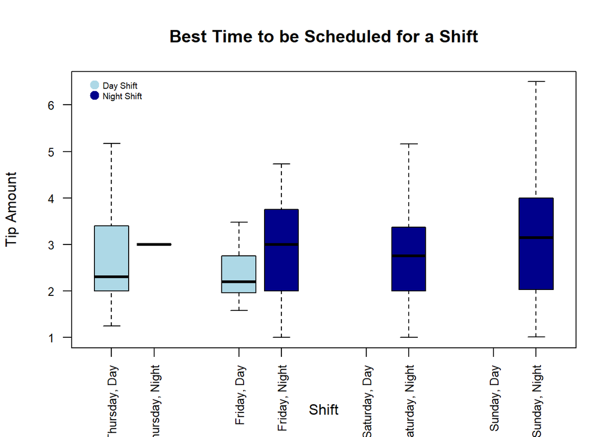

The above boxplots tell us which shifts are optimal for if you desire to earn the most tips. This does not take into account the total bill amount, because if a server solely cares about tips, they will care less about how generous of a tip a party gives and more about the total tips they are able to generate during their shift, regardless of how much a party’s total bill is.

Besides higher tipping due to drinking, higher averages on weekends might be attributed to larger parties visiting on the weekend. Since this would raise the total bill, we can expect the total tip to be higher.

Ultimately, as a server, if you are looking at the opportunity to make high tips while still guaranteeing a decent tip, Sunday night would be best, followed by Friday night. Getting a Thursday night shift, or a satuday and sunday day shift should be avoided due to the (sometimes complete) lack of customers.